# 2_HMM_accelerometer

Dennis Kim

2026-04-03

This document presents the analysis of accelerometer data from Maned wolves at Parque Nacional da Serra da Canastra in Brazil, kindly made available by Rosanna N. Moraes. Here we focus on two individuals of the wild maned wolves (one male - ID 32866 aka. Juba and one femail - ID 32733 - Pacoca). Juba and Pacoca are a couple and Pacoca was pregnant when she was fitted with the accelerometer.

```r
# Movement modelling package
library(momentuHMM)
# Data wrangling packages
library(data.tree)
library(dplyr)
library(tidyr)
library(lubridate)
library(readr)
library(zoo)
# Visualization
library(ggplot2)
```

# 1. Load data: activity summary data

We first load the data directly from the file location. The original data were saved as .adf file format and you need to convert them to R-readabale file such as .csv format through vendoring software such as GPS Plus X. For the purposes of this demonstration, we take the summarized activity data from the raw accelerometer data from two individuals the fitted wild maned wolves: ID 32866-Juba and ID 32733-Pacoca. The accelerometer data is different than the GPS data where tracks activity patterns of the wolves at much finer temporal scales.

```r
# Load data

## ID: 32733 - pacoca
act_32733 <- read.csv("data/32733_PACOCA/ACT_Collar32733_20260401143616.csv")

## ID: 32866 - juba
act_32866 <- read.csv("data/32866_JUBA/ACT_Collar32866_20260401143833.csv")
```

# 2. Clean timestamps

Before looking at the time interval range, look at the raw data closely that currently the data contains separate data and time columns. We use “UTC” timezone dataset and the column ‘UTC_Date’ contains mm/dd/yy and ‘UTC_Time’ includes hh/mm/ss. Both columns are currently characters. First, let’s create a correctly formatted time column.

```r
## currently, the data contains several date/time columns -- date and time need to combine into one column first
act_32733$datetime_str <- paste(act_32733$UTC_Date, act_32733$UTC_Time)
act_32866$datetime_str <- paste(act_32866$UTC_Date, act_32866$UTC_Time)

## convert to POSIXct
act_32733$time <- lubridate::mdy_hms(act_32733$datetime_str, tz = "UTC")
act_32866$time <- lubridate::mdy_hms(act_32866$datetime_str, tz = "UTC")
```

The base time interval between observations was 5 minutes (300 secs) in this study. Make sure to check if there were missing observations, resulting in longer intervals.

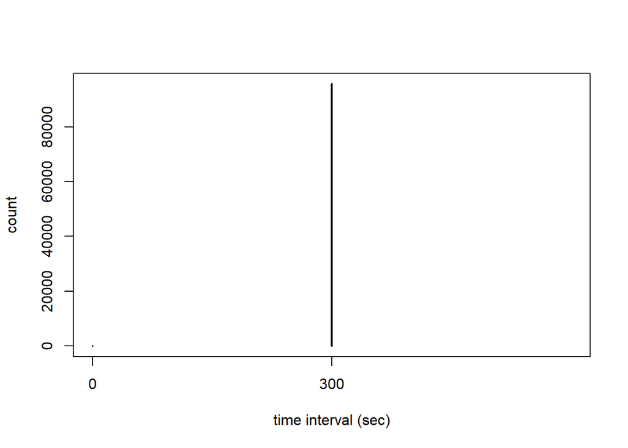

```r
# Table of time intervals in data - can apply to both individuals
plot(table(diff(act_32866$time)), xlim = c(0, 600),
     xlab = "time interval (sec)", ylab = "count")
```

Although our data do not have issues with temporal irregularity in the data, it is always important to check and deal with temporal irregularity before fitting the HMMs.

## Create a single summary activity variable

Unlike GPS data, activity data do not include location information such as coordinates (e.g., Easting/Northing or latitude/longitude). Instead, activity data capture movement using proxy variables (in our data, they are labeled as ‘ActivityX’, ‘ActivityY’, and ‘ActivityZ’), which measure motion along three dimensions. These values are recorded at regular intervals (e.g., every 5 minutes) and reflect how the animal is moving rather than where it is.

These three measurements are often combined into a single summary metric called **Overall Dynamic Body Acceleration (ODBA)**, which represents the overall intensity of movement and is commonly used as an indicator of activity level or energy expenditure. Let’s calculate ODBA for our data.

```r
## use a single summary activity variable - ODBA
act_32733$ODBA <- rowSums(act_32733[, c("ActivityX", "ActivityY", "ActivityZ")], na.rm= TRUE)
act_32866$ODBA <- rowSums(act_32866[, c("ActivityX", "ActivityY", "ActivityZ")], na.rm = TRUE)
```

## Further minor data wrangling

Let’s select several columns of interest for the analysis and combine individual data into one.

```r
# select the columns of interest
pacoca <- act_32733 %>% dplyr::select(CollarID, ODBA, time, Temp...C.)
juba <- act_32866 %>% dplyr::select(CollarID, ODBA, time, Temp...C.)

# change the name of the columns
colnames(pacoca)[1] <- "ID"
colnames(juba)[1] <- "ID"
colnames(pacoca)[4] <- "temp"
colnames(juba)[4] <- "temp"

# combine the datasets
data <- rbind(pacoca, juba)

summary(data)
```

```
       ID             ODBA            time                          temp
 Min.   :32733   Min.   :  0.0   Min.   :2022-06-21 06:55:00   Min.   : 8.00
 1st Qu.:32733   1st Qu.:  0.0   1st Qu.:2022-11-02 23:20:00   1st Qu.:21.00
 Median :32733   Median : 12.0   Median :2023-01-25 14:07:30   Median :23.00
 Mean   :32799   Mean   :120.6   Mean   :2023-01-25 02:46:26   Mean   :24.24
 3rd Qu.:32866   3rd Qu.:254.0   3rd Qu.:2023-04-19 04:55:00   3rd Qu.:28.00
 Max.   :32866   Max.   :510.0   Max.   :2023-07-19 16:55:00   Max.   :48.00
```

# 3. The momentuHMM workflow

## Data preparation

The data are now ready to be used in momentuHMM. Note that we do not handle the location data like the GPS example. In the GPS data, we derive step lengths and turning angles from the locations. Here, we set ‘coordNames’ argument to NULL within the function ‘prepData’.

```r
# Prepare data for HMM
data_hmm <- prepData(data, coordNames = NULL, covNames = "temp")
```

## Model fitting

We can now fit a HMM, which is done with the function ‘fitHMM’. In this example, we focus **only on activity data** (ODBA), although momentuHMM can also handle multiple datastreams, e.g., GPS data for coarse-scale movements.

We are interested in two states: state 1: low activity and state 2: high activity.

Two thing need to be specified before model fitting:

- Observation distributions: Each observed varaiable needs a probability distribution for each state. ODBA is continuous and strictly positive (except for exact zeros), so a gamma distribution is appropriate. Note that our data contains many zero but momentuHMM allows zero-inflated gamma.
- Initial parameter values: ‘fitHMM’ function uses numerical optimization to find maximum likelihood estimates. The optimization rquires a starting point. For a gamma distriution with zero-inflation, each state requires three parameters: (1) mean of the gamma, (2) standard deviation of the gamma, and (3) probability of exact zero (i.e., zero-mass) for each state.

Choosing initial parameter values are very tricky and there is some guidance for selecting initial paramter values provided in a vignette for the R package moveHMM: [A short guide to choosing initial parameter values for the estimation in moveHMM](https://cran.r-project.org/web/packages/moveHMM/vignettes/moveHMM-starting-values.pdf).

```r
# Observation distributions (ODBA)
dist <- list(ODBA = "gamma")

# Initial parameters
# Use simple rules-of-thumb based on the data:
# - Low activity state (state 1): roughly half the mean ODBA
# - High activity state (state 2): roughly 1.5 times the mean ODBA
mu1 <- max(mean(data$ODBA) * 0.5, 1e-2)  # state 1: low activity
mu2 <- max(mean(data$ODBA) * 1.5, 1e-2)  # state 2: high activity

# Use the standard deviation of the positive observations as a guide.
# Ensure strictly positive values (1e-2) to satisfy momentuHMM bounds.
sd1 <- max(sd(data$ODBA) * 0.5, 1e-2)
sd2 <- max(sd(data$ODBA) * 1.5, 1e-2)

# Zero-inflation: probability of observing exact zeros
# Can estimate from data, or use small non-zero values as starting points -- Must be strictly < 1
zm1 <- 0.01
zm2 <- 0.01

# Combine into Par0
# The order is important: c(mu1, mu2, sd1, sd2, zm1, zm2)
Par0_2s <- list(
  ODBA = c(mu1, mu2, sd1, sd2, zm1, zm2)
)

# Fit a 2-state HMM
hmm1 <- fitHMM(data_hmm, nbStates = 2, dist = dist, Par0 = Par0_2s)

# Print paramter estimates
hmm1
```

```
Value of the maximum log-likelihood: -764993.8


ODBA parameters:
----------------
            state 1       state 2
mean      9.9848575  2.673456e+02
sd       10.8542678  9.340152e+01
zeromass  0.5451819 4.584242e-158

Regression coeffs for the transition probabilities:
---------------------------------------------------
               1 -> 2    2 -> 1
(Intercept) -3.501952 -3.258972

Transition probability matrix:
------------------------------
           state 1    state 2
state 1 0.97074327 0.02925673
state 2 0.03700583 0.96299417

Initial distribution:
---------------------
  state 1   state 2
0.3236868 0.6763132
```

## Model visualization

The model is fitted, we can print the parameter estimates, as well as plot some outputs

```
Decoding state sequence... DONE
```

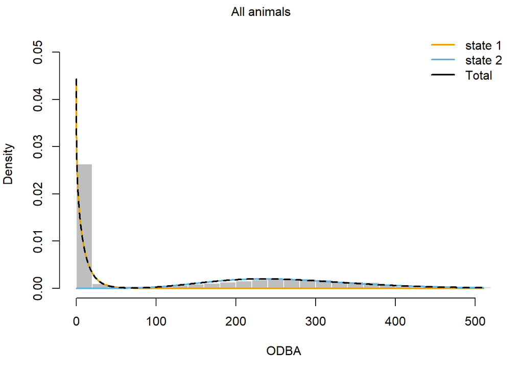

```r
# Plot estimated distributions and state-coloured tracks
plot(hmm1, breaks = 25, ask = FALSE)
```

We can also estimate the most likely state sequence for a fitted model with the funection ‘viterbi’ algorithm.

```r
# get most likely sequence of states
head(viterbi(hmm1))
```

```
[1] 1 1 1 1 1 1
```

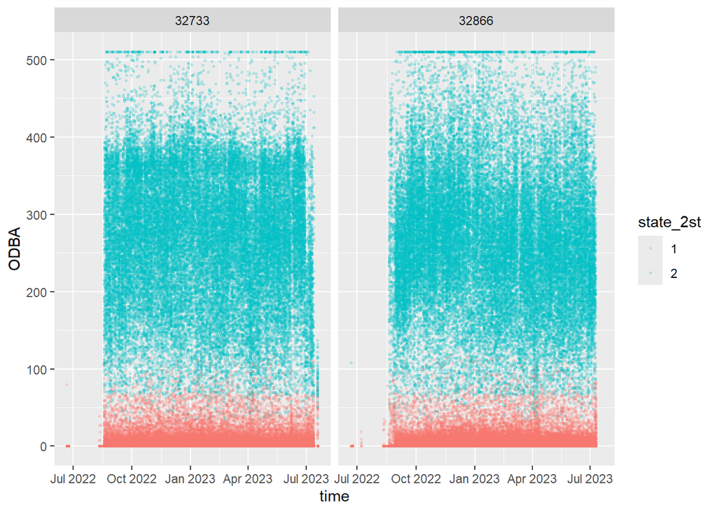

```r
# save most likely state sequence from 2-state model
data_hmm$state_2st <- factor(viterbi(hmm1))

# plot OBDA over time, colored by states
ggplot(data_hmm, aes(x = time, y = ODBA, col = state_2st, group = ID))+
  geom_point(size = 0.5, alpha = 0.2)+
  facet_wrap(~ID)
```

## Model formulation: covariates

We have temperature measurements taken by the tag at each time of observation. How does temperature tned to affect the wolves’ activity patterns? Let’s estimate the effect of covariates on the transition probabilities.

```r
# Fit 2-state HMM with temperature covariate
hmm2 <- momentuHMM::fitHMM(data_hmm, nbStates = 2, dist = dist, Par0 = Par0_2s, formula = ~temp)

# show summary of model 2
hmm2
```

```
Value of the maximum log-likelihood: -764619.2


ODBA parameters:
----------------
            state 1      state 2
mean      9.8975451 2.672330e+02
sd       10.7206087 9.355548e+01
zeromass  0.5454623 5.549735e-08

Regression coeffs for the transition probabilities:
---------------------------------------------------
                  1 -> 2     2 -> 1
(Intercept) -3.519456956 -5.8559552
temp         0.001075723  0.1069292

Transition probability matrix (based on mean covariate values):
---------------------------------------------------------------
           state 1    state 2
state 1 0.97049876 0.02950124
state 2 0.03684042 0.96315958

Initial distribution:
---------------------
  state 1   state 2
0.3586157 0.6413843
```

Let’s visualizae the stationary state probabilities as functions of the temperature covariate.

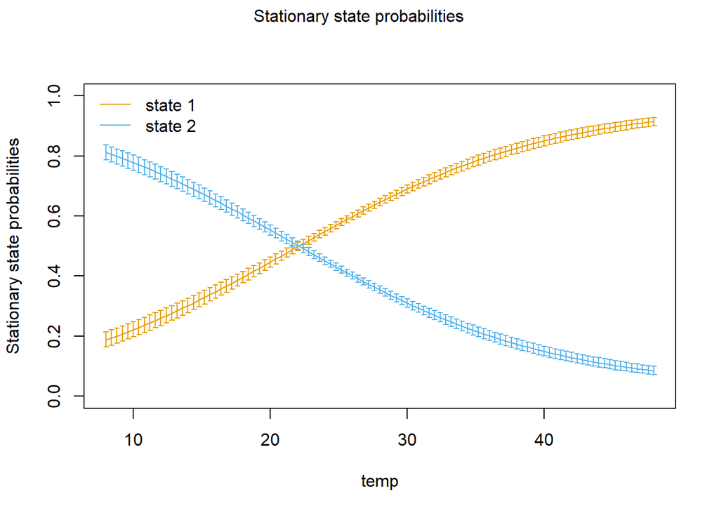

```r
# plot stationary state probabilities as functions of temperature
plotStationary(hmm2, plotCI = TRUE)
```

This plot suggests that the wolves were more likely to be in state 2 (high activity) at low temperatures, and in state 1 (low activity) at high temperatures.

## Model comparison

We can use the ‘AIC’ function for model selection by comparing the model without the covariate versus model with the temperature covariate.

```r
# Compare models using AIC
AIC(hmm1, hmm2)
```

```
  Model     AIC
1  hmm2 1529260
2  hmm1 1530006
```

The AIC slightly favors the model with the temperature covariate.

## Model checking

We can further evaluate whether a model sufficiently represents the key characteristics of the data. One common method of model checking for HMMs is pseudo-residuals. When the model provides a perfect fit, these pseudo-residuals should follow a standard normal distribution. Any departure from this pattern may suggest that the model does not fully capture the data structure.

The ‘plotPR’ function can be used to genereates three diagnostic plots for each variable:

- A time series plot
- A quantile-quantile (QQ) plot comparing the reisduals to a standard normal distribution
- An autocorrelation function (ACF) plot.

Deviations from the diagnoal line in the QQ plot signal potential lack of fit, while the ACF plot helps determine whether the model has successfully accounted for temporal dependence in the data.

```
Computing pseudo-residuals...
```

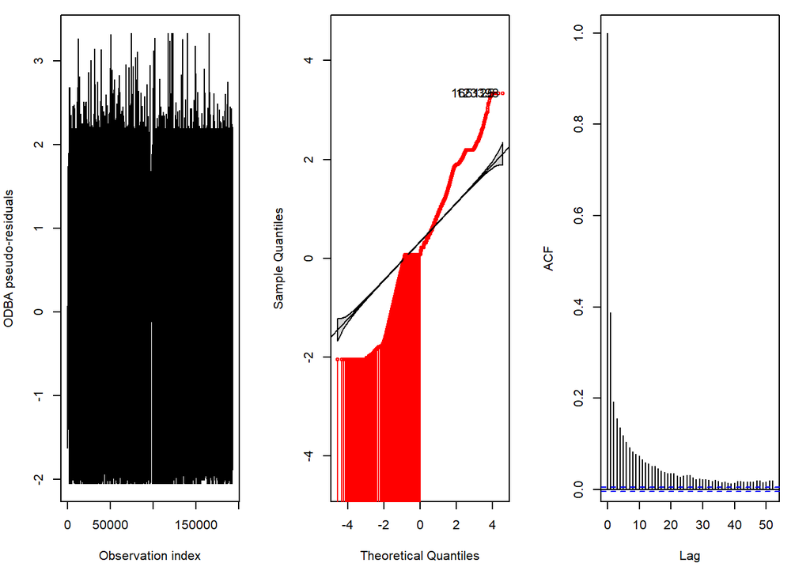

```r
# plot pseudo-residuals for 2-state models
plotPR(hmm1)
```

```
Computing pseudo-residuals...
```

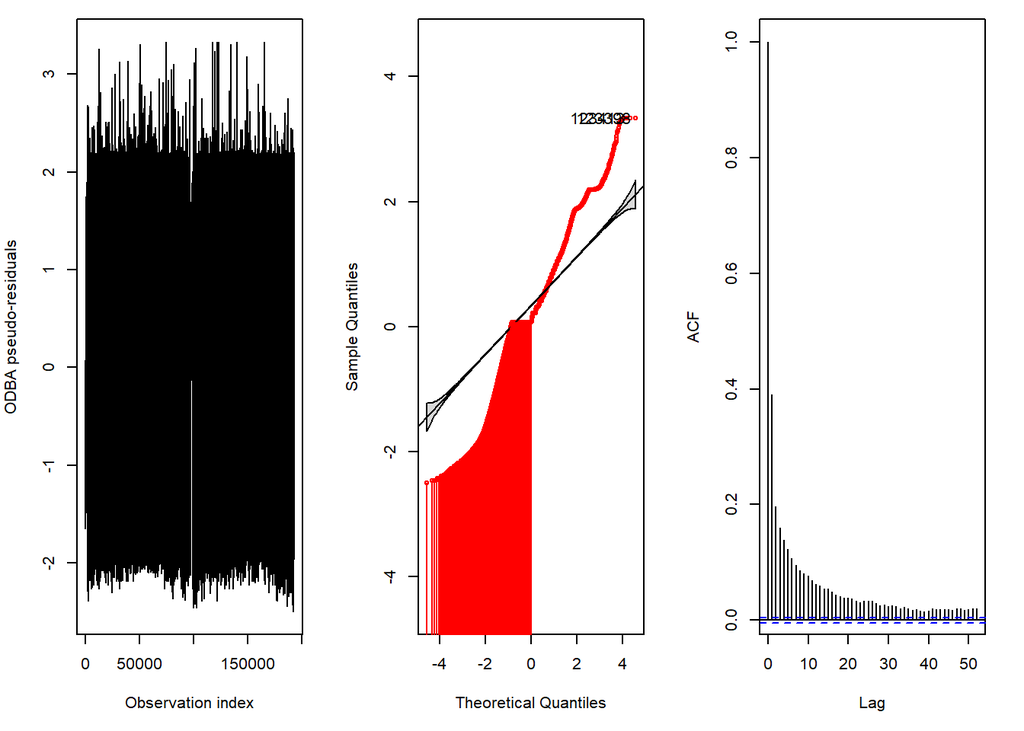

```r
plotPR(hmm2)
```

Goodness-of-fit is slightly better for the model 2. However, the model still needs to be tuned to capture more detailed features of the data. This is a good example of how it is important to do model checking before finalizing the model.